# Epidemic curves

#### Color by groups

**Designate a column containing groups**

In any of the code template (Sunday weeks, Monday weeks), make the following changes:

- Add the *aesthetics* argument `aes()` within the `geom_histogram()` (don’t forget comma afterward)
- **Within `aes()`**, provide the grouping column name to `group =` and `fill =` (no quotes needed). `group` is necessary, while `fill` changes the color of the bar.
- Remove any `fill =` argument outside of the `aes()`, as it will override the one inside
- Arguments *inside* `aes()` will apply by group, whereas any *outside* will apply to all bars (e.g. you may want `color =` outside, so each bar has the same color perimeter/border)

```
geom_histogram(
    aes(group = gender, fill = gender))
```

**Adjust colors**:

- To manually adjust the bar fill color of each group, use `scale_fill_manual()` (note `scale_color_manual()` is different!).
  - Use the `values =` argument to apply a vector of colors.
  - Use `na.value =` to specify a color for missing values.
  - ! While you *can* use the `labels =` argument in `scale_fill_manual()` change the legend text labels - it is easy to accidentally give labels in the incorrect order and have an incorrect legend! It is recommended to instead convert the group column to class Factor and designate factor `labels` and order, as explained below.
- To adjust the colors via a **color scale**, see the page on ggplot tips

**Adjust the stacking order and Legend**

Stacking order, and the labels for each group in the legend, is best adjusted by classifying the group column as class Factor. You can then designate the levels and their labels, and the order (which is reflected in stack order).

Step 1: Before making the ggplot, convert the `group` column to class Factor using `factor()` from **base** R.  
For example, with a column “gender” with values “m” and “f” and `NA`, this can be put in a `mutate()` command as:

```
dataset <- dataset %>%
  mutate(gender = factor(gender,
                    levels = c(NA, "f", "m"),
                    labels = c("Missing", "Female", "Male"),
                    exclude = NULL))
```

The above code establishes the levels, in the ordering that missing values are “first” (and will appear on top). Then the labels that will show are given in the same order. Lastly, the exclude statement ensures that `NA` is included in the ordering (by default `factor()` ignores `NA`).

**Adjusting the legend**

Read more about legends in the ggplot tips page. Here are a few highlights:

- `theme(legend.position = "top")` (or “bottom”, “left”, “right”)
- `theme(legend.direction = "horizontal")`
- `theme(legend.title = element_blank())` to have no title

See the page of ggplot() tips for more details on legends.

These steps are shown in the example below:

*Click “Code” to see the code*

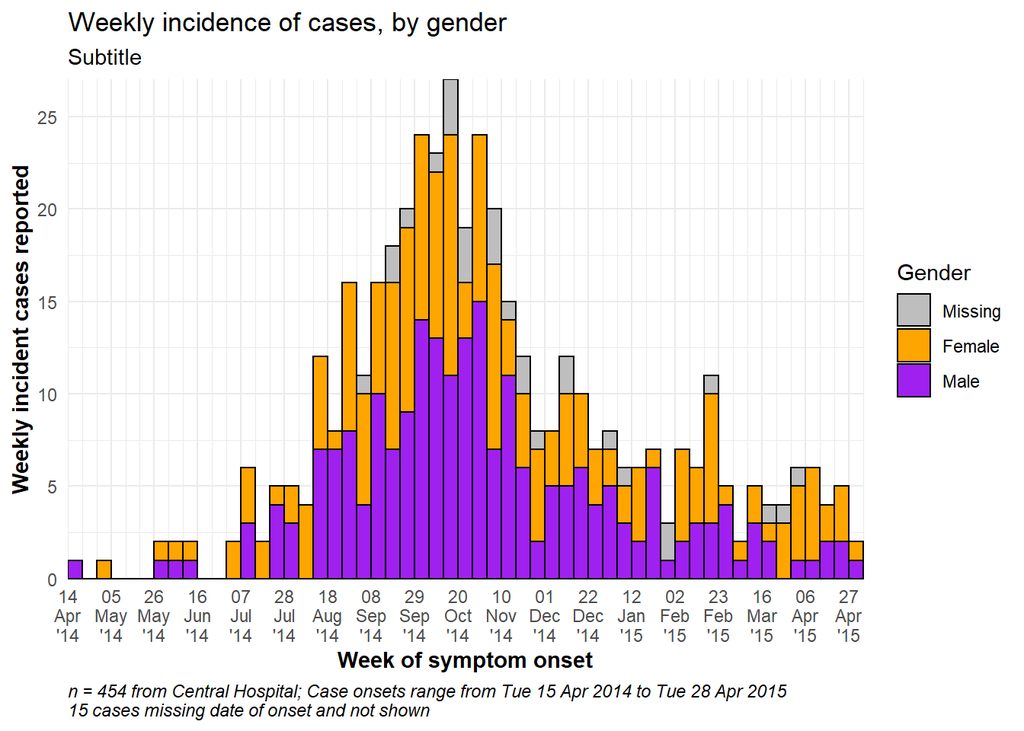

```r
########################
# bin break points for histogram defined here for clarity
# starts the Monday before first case, end Monday after last case
bin_breaks = seq.Date(
  from = as.Date(floor_date(min(central_data$date_onset, na.rm=T),   "week", week_start = 1)),
  to   = as.Date(ceiling_date(max(central_data$date_onset, na.rm=T), "week", week_start = 1)),
  by   = "7 days") # bins are 7-days

# Set gender as factor and missing values as first level (to show on top)
central_data <- linelist %>%
  filter(hospital == "Central Hospital") %>%
  mutate(gender = factor(
    gender,
    levels = c(NA, "f", "m"),
    labels = c("Missing", "Female", "Male"),
    exclude = NULL))

# make plot
###########
ggplot(central_data, aes(x = date_onset)) +
  geom_histogram(
    aes(group = gender, fill = gender),    # arguments inside aes() apply by group
    color = "black",                       # arguments outside aes() apply to all data
    breaks = bin_breaks)+                  # see breaks defined above


  # The labels on the x-axis
  scale_x_date(
    expand            = c(0,0),         # remove excess x-axis space below and after case bars
    date_breaks       = "3 weeks",      # labels appear every 3 Monday weeks
    date_minor_breaks = "week",         # vertical lines appear every Monday week
    date_labels       = "%d\n%b\n'%y")+ # date labels format

  # y-axis
  scale_y_continuous(
    expand = c(0,0))+                   # removes excess y-axis space between bottom of bars and the labels

  #scale of colors and legend labels
  scale_fill_manual(
    values = c("grey", "orange", "purple"))+ # specify fill colors ("values") - attention to order!

  # aesthetic themes
  theme_minimal()+                                               # a set of themes to simplify plot
  theme(
    plot.caption = element_text(face = "italic", hjust = 0), # caption on left side in italics
    axis.title = element_text(face = "bold"))+               # axis titles in bold

  # labels
  labs(
    title    = "Weekly incidence of cases, by gender",
    subtitle = "Subtitle",
    fill     = "Gender",                                      # provide new title for legend
    x        = "Week of symptom onset",
    y        = "Weekly incident cases reported",
    caption  = stringr::str_glue("n = {nrow(central_data)} from Central Hospital; Case onsets range from {format(min(central_data$date_onset, na.rm=T), format = '%a %d %b %Y')} to {format(max(central_data$date_onset, na.rm=T), format = '%a %d %b %Y')}\n{nrow(central_data %>% filter(is.na(date_onset)))} cases missing date of onset and not shown"))
```

**Display bars side-by-side**

Side-by-side display of group bars (as opposed to stacked) is specified within `geom_histogram()` with `position = "dodge"`.  
If there are more than two value groups, these can become difficult to read. Consider instead using a faceted plot (small multiples) (see tab). To improve readability in this example, missing gender values are removed.

*Click “Code” to see the code*

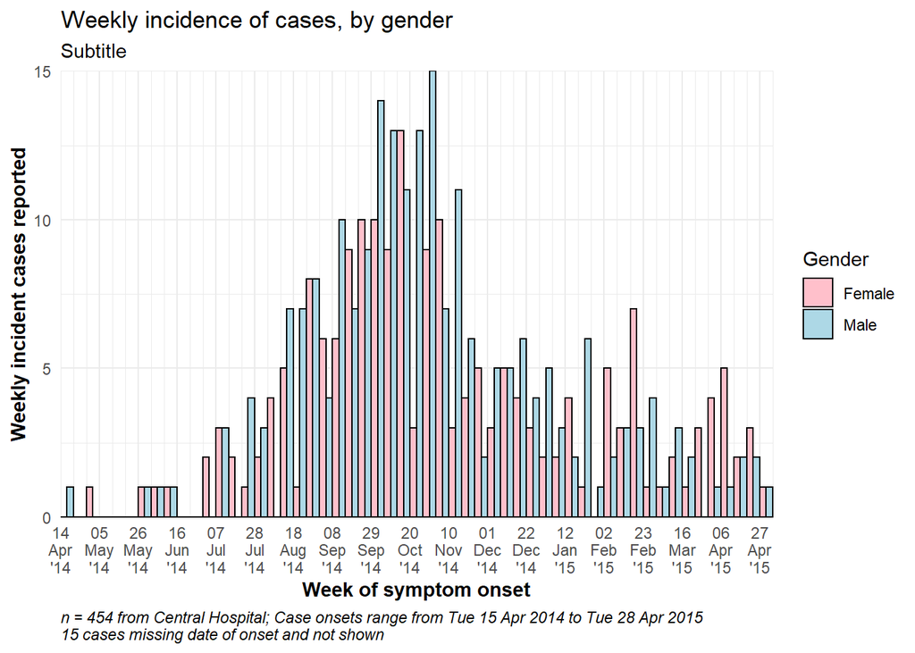

```r
########################
# bin break points for histogram defined here for clarity
# starts the Monday before first case, end Monday after last case
bin_breaks = seq.Date(from = as.Date(floor_date(min(central_data$date_onset, na.rm=T),   "week", week_start = 1)),
                      to   = as.Date(ceiling_date(max(central_data$date_onset, na.rm=T), "week", week_start = 1)),
                      by   = "7 days") # bins are 7-days

# New dataset without rows missing gender
central_data_dodge <- linelist %>%
  filter(hospital == "Central Hospital") %>%
  filter(!is.na(gender)) %>%                            # remove rows missing gender
  mutate(gender = factor(gender,                        # factor now has only two levels (missing not included)
                         levels = c("f", "m"),
                         labels = c("Female", "Male")))

# make plot
###########
ggplot(central_data_dodge, aes(x = date_onset)) +
    geom_histogram(
        aes(group = gender, fill = gender),    # arguments inside aes() apply by group
        color = "black",                       # arguments outside aes() apply to all data
        breaks = bin_breaks,
        position = "dodge")+                  # see breaks defined above


  # The labels on the x-axis
  scale_x_date(expand            = c(0,0),         # remove excess x-axis space below and after case bars
               date_breaks       = "3 weeks",      # labels appear every 3 Monday weeks
               date_minor_breaks = "week",         # vertical lines appear every Monday week
               date_labels       = "%d\n%b\n'%y")+ # date labels format

  # y-axis
  scale_y_continuous(expand = c(0,0))+                   # removes excess y-axis space between bottom of bars and the labels

  #scale of colors and legend labels
  scale_fill_manual(values = c("pink", "lightblue"))+     # specify fill colors ("values") - attention to order!

  # aesthetic themes
  theme_minimal()+                                               # a set of themes to simplify plot
  theme(plot.caption = element_text(face = "italic", hjust = 0), # caption on left side in italics
        axis.title = element_text(face = "bold"))+               # axis titles in bold

  # labels
  labs(title    = "Weekly incidence of cases, by gender",
       subtitle = "Subtitle",
       fill     = "Gender",                                      # provide new title for legend
       x        = "Week of symptom onset",
       y        = "Weekly incident cases reported",
       caption  = stringr::str_glue("n = {nrow(central_data)} from Central Hospital; Case onsets range from {format(min(central_data$date_onset, na.rm=T), format = '%a %d %b %Y')} to {format(max(central_data$date_onset, na.rm=T), format = '%a %d %b %Y')}\n{nrow(central_data %>% filter(is.na(date_onset)))} cases missing date of onset and not shown"))
```

#### Faceting/small-multiples

As with other ggplots, you can create facetted plots (“small multiples”) off values in a column. As explained in the ggplot tips page of this handbook, you can use either:

- `facet_wrap()`
- `facet_grid()`

For epicurves, `facet_wrap()` is typically easiest as it is likely that you only need to facet on one column. The general syntax is `facet_wrap(rows ~ cols)`, where to the left of the tilde (~) is the name of a column to be spread across the “rows” of the new plot, and to the right of the tilde is the name of a column to be spread across the “columns” of the new plot.

**Most simply, just use one column name, to the right of the tilde**: `facet_wrap(~age_cat)`.

**Free axes**  
You will need to decide whether the scales (`scales =`) of the axes for each facet are “fixed” to the same dimensions (default), or “free” (meaning they will change based on the data within the facet). You can also specify “free_x” or “free_y” to release in only one dimension.

**Number of cols and rows**  
This can be specified with `ncol =` and `nrow =` within `facet_wrap()`.

**Order of panels**  
To change the order of appearance, change the underlying order of the levels of the factor column used to create the facets.

**Aesthetics**  
Font size and face, strip color, etc. can be modified through `theme()` with arguments like:

- `strip.text = element_text()` (size, colour, face, angle…)
- `strip.background = element_rect()` (e.g. element_rect(fill=“red”))

The position of the strip can be modified as the `strip.position =` argument within `facet_wrap()` (e.g. “bottom”, “top”, “left”, “right”)

**Strip labels**  
Labels of the facet plots can be modified through the “labels” of the column as a factor, or by the use of a “labeller”.

Make a labeller like this, using the function `as_labeller()` from **ggplot2**:

```r
my_labels <- as_labeller(c(
     "0-4"   = "Ages 0-4",
     "5-9"   = "Ages 5-9",
     "10-14" = "Ages 10-14",
     "15-19" = "Ages 15-19",
     "20-29" = "Ages 20-29",
     "30-49" = "Ages 30-49",
     "50-69" = "Ages 50-69",
     "70+"   = "Over age 70"))
```

**An example plot**  
Faceted by column `age_cat`. Click “Code” to see the code.

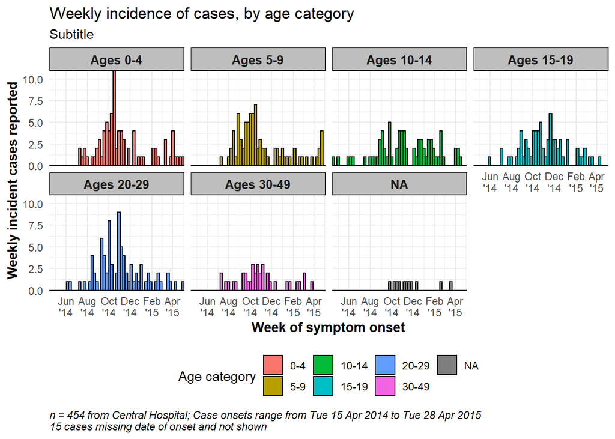

```r
# make plot
###########
ggplot(central_data, aes(x = date_onset)) +

  geom_histogram(
        aes(group = age_cat, fill = age_cat),    # arguments inside aes() apply by group
        color = "black",                       # arguments outside aes() apply to all data
        breaks = bin_breaks)+                  # see breaks defined above



  # The labels on the x-axis
  scale_x_date(expand            = c(0,0),         # remove excess x-axis space below and after case bars
               date_breaks       = "2 months",     # labels appear every 2 months
               date_minor_breaks = "1 month",      # vertical lines appear every 1 month
               date_labels       = "%b\n'%y")+     # date labels format

  # y-axis
  scale_y_continuous(expand = c(0,0))+                   # removes excess y-axis space between bottom of bars and the labels

  # aesthetic themes
  theme_minimal()+                                               # a set of themes to simplify plot
  theme(plot.caption = element_text(face = "italic", hjust = 0), # caption on left side in italics
        axis.title = element_text(face = "bold"),
        legend.position = "bottom",
        strip.text = element_text(face = "bold", size = 10),
        strip.background = element_rect(fill = "grey"))+               # axis titles in bold

  # create facets
  facet_wrap(~age_cat,
             ncol = 4,
             strip.position = "top",
             labeller = my_labels)+

  # labels
  labs(title    = "Weekly incidence of cases, by age category",
       subtitle = "Subtitle",
       fill     = "Age category",                                      # provide new title for legend
       x        = "Week of symptom onset",
       y        = "Weekly incident cases reported",
       caption  = stringr::str_glue("n = {nrow(central_data)} from Central Hospital; Case onsets range from {format(min(central_data$date_onset, na.rm=T), format = '%a %d %b %Y')} to {format(max(central_data$date_onset, na.rm=T), format = '%a %d %b %Y')}\n{nrow(central_data %>% filter(is.na(date_onset)))} cases missing date of onset and not shown"))
```

See this [link](https://ggplot2.tidyverse.org/reference/labellers.html) for more information on labellers.

**Add total epidemic to background**  
Add a separate `geom_histogram()` command *before* the current one. Specify that the data used is the data *without* the column used for faceting (see `select()`). Then, specify a color like “grey” and a degree of transparency to make it appear in the background.

```
geom_histogram(data = select(central_data, -age_cat), color = "grey", alpha = 0.5)+
```

Note that the y-axis maximum is now based on the height of the entire epidemic. Click “Code” to see the code.

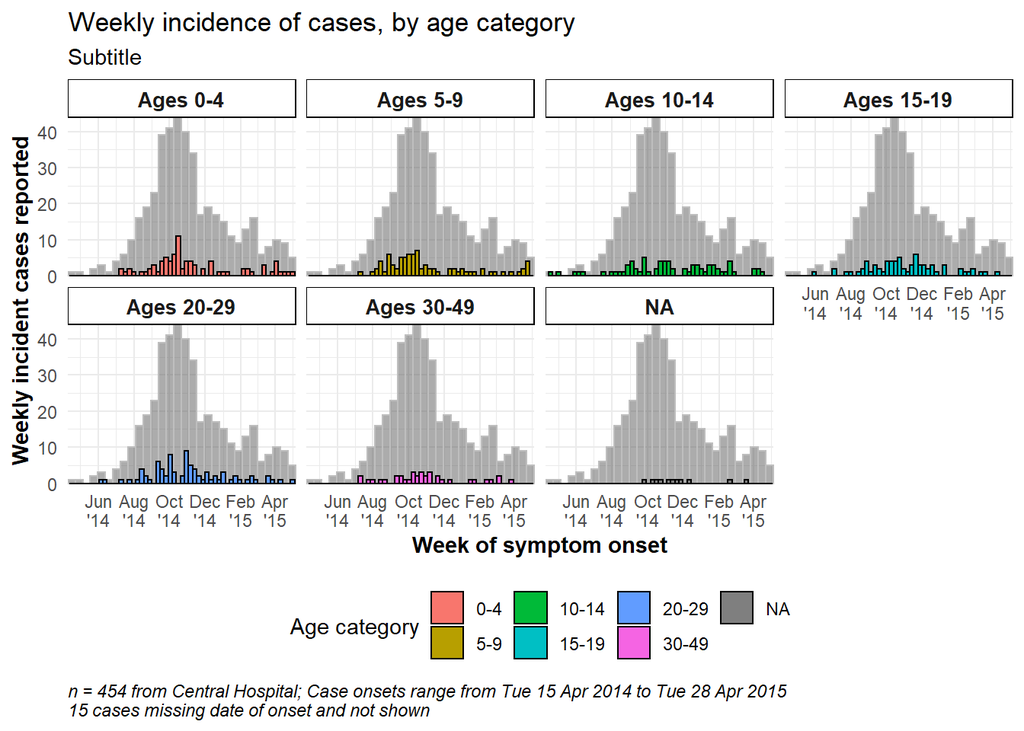

```r
ggplot(central_data, aes(x = date_onset)) +

  # for background shadow of whole outbreak
  geom_histogram(data = select(central_data, -age_cat), color = "grey", alpha = 0.5)+

  # actual epicurves by group
  geom_histogram(
        aes(group = age_cat, fill = age_cat),  # arguments inside aes() apply by group
        color = "black",                       # arguments outside aes() apply to all data
        breaks = bin_breaks)+                  # see breaks defined above

  # Labels on x-axis
  scale_x_date(expand            = c(0,0),         # remove excess x-axis space below and after case bars
               date_breaks       = "2 months",     # labels appear every 2 months
               date_minor_breaks = "1 month",      # vertical lines appear every 1 month
               date_labels       = "%b\n'%y")+     # date labels format

  # y-axis
  scale_y_continuous(expand = c(0,0))+                   # removes excess y-axis space between bottom of bars and the labels

  # aesthetic themes
  theme_minimal()+                                               # a set of themes to simplify plot
  theme(plot.caption = element_text(face = "italic", hjust = 0), # caption on left side in italics
        axis.title = element_text(face = "bold"),
        legend.position = "bottom",
        strip.text = element_text(face = "bold", size = 10),
        strip.background = element_rect(fill = "white"))+               # axis titles in bold

  # create facets
  facet_wrap(~age_cat,                          # each plot is one value of age_cat
             ncol = 4,                          # number of columns
             strip.position = "top",            # position of the facet title/strip
             labeller = my_labels)+             # labeller defines above

  # labels
  labs(title    = "Weekly incidence of cases, by age category",
       subtitle = "Subtitle",
       fill     = "Age category",                                      # provide new title for legend
       x        = "Week of symptom onset",
       y        = "Weekly incident cases reported",
       caption  = stringr::str_glue("n = {nrow(central_data)} from Central Hospital; Case onsets range from {format(min(central_data$date_onset, na.rm=T), format = '%a %d %b %Y')} to {format(max(central_data$date_onset, na.rm=T), format = '%a %d %b %Y')}\n{nrow(central_data %>% filter(is.na(date_onset)))} cases missing date of onset and not shown"))
```

**Create one facet with ALL data**  
To do this, you duplicate all the data (double the number of rows in the dataset) and in the faceted column have a new value (e.g. “all”) which indicates all the duplicated rows. A helped function is below that enables this:

```r
# Define helper function
CreateAllFacet <- function(df, col){
     df$facet <- df[[col]]
     temp <- df
     temp$facet <- "all"
     merged <-rbind(temp, df)

     # ensure the facet value is a factor
     merged[[col]] <- as.factor(merged[[col]])

     return(merged)
}

# Create dataset that is duplicated, to show "all zones" as another facet level
central_data2 <- CreateAllFacet(central_data, col = "age_cat") %>%
  mutate(facet = factor(facet,
                        levels = c("all", "0-4", "5-9", "10-14", "15-19", "20-29", "30-49", "50-69", "70+")))

# check
table(central_data2$facet, useNA = "always")
```

```
##
##   all   0-4   5-9 10-14 15-19 20-29 30-49 50-69   70+  <NA>
##   454    84    87    77    73    84    37     0     0    12
```

Notable changes to the ggplot command are:

- The data used is now central_data2 (double the rows, with new column “facet”)
- Labeller will need to be updated, if used
- To achieve long/thin plot, facet variable moved to rows side of equation, replaced by “.” `facet_wrap(facet~.)`, and `ncol = 1`

You may also need to adjust the width and height of the save plot image (see `ggsave()`).

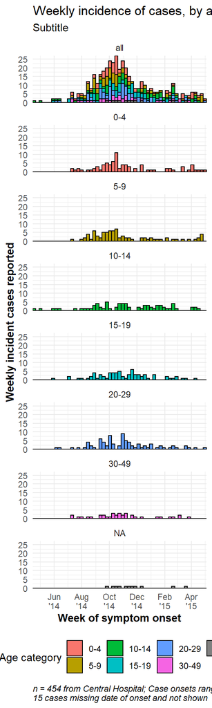

```r
ggplot(central_data2, aes(x = date_onset)) +

  # actual epicurves by group
  geom_histogram(
        aes(group = age_cat, fill = age_cat),  # arguments inside aes() apply by group
        color = "black",                       # arguments outside aes() apply to all data
        breaks = bin_breaks)+                  # see breaks defined above

  # Labels on x-axis
  scale_x_date(expand            = c(0,0),         # remove excess x-axis space below and after case bars
               date_breaks       = "2 months",     # labels appear every 2 months
               date_minor_breaks = "1 month",      # vertical lines appear every 1 month
               date_labels       = "%b\n'%y")+     # date labels format

  # y-axis
  scale_y_continuous(expand = c(0,0))+                   # removes excess y-axis space between bottom of bars and the labels

  # aesthetic themes
  theme_minimal()+                                               # a set of themes to simplify plot
  theme(plot.caption = element_text(face = "italic", hjust = 0), # caption on left side in italics
        axis.title = element_text(face = "bold"),
        legend.position = "bottom")+

  # create facets
  facet_wrap(facet~. ,                            # each plot is one value of facet
             ncol = 1)+

  # labels
  labs(title    = "Weekly incidence of cases, by age category",
       subtitle = "Subtitle",
       fill     = "Age category",                                      # provide new title for legend
       x        = "Week of symptom onset",
       y        = "Weekly incident cases reported",
       caption  = stringr::str_glue("n = {nrow(central_data)} from Central Hospital; Case onsets range from {format(min(central_data$date_onset, na.rm=T), format = '%a %d %b %Y')} to {format(max(central_data$date_onset, na.rm=T), format = '%a %d %b %Y')}\n{nrow(central_data %>% filter(is.na(date_onset)))} cases missing date of onset and not shown"))
```

#### Moving averages

Add a moving averages to a `ggplot()` epicurve in one of two ways:

1. Plot the pre-calculated moving average:
   - Aggregate the data as necessary (daily, weekly, etc.)
   - Calculate the moving average
   - Add the moving average to the ggplot (e.g. with `geom_line()`)
2. Calculate on-the-fly within the `ggplot()` command

##### **Using slider**

In this approach, the moving average is calculated in the dataset prior to plotting:

- Within `mutate()`, a new column is created to hold the average. `slide_index()` from **slider** package is used as shown below.
- In the `ggplot()`, a `geom_line()` is added after the histogram, reflecting the moving average.

See the helpful online [vignette for the **slider** package](https://cran.r-project.org/web/packages/slider/vignettes/slider.html)

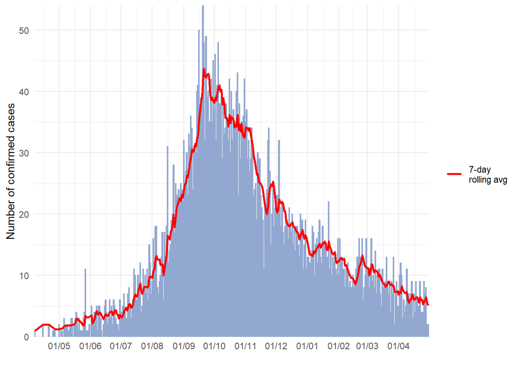

```r
pacman::p_load(slider)  # slider used to calculate rolling averages

# make dataset of daily counts and 7-day moving average
#######################################################
ll_counts_7day <- linelist %>%
  ## count cases by date
  count(date_onset,
        name = "new_cases") %>%   # name of new column
  filter(!is.na(date_onset)) %>%  # remove cases with missing date_onset

  ## calculate the average number of cases in the preceding 7 days
  mutate(
    avg_7day = slider::slide_index(    # create new column
      new_cases,                       # calculate based on value in new_cases column
      .i = date_onset,                 # index is date_onset col, so non-present dates are included in window
      .f = ~mean(.x, na.rm = TRUE),    # function is mean() with missing values removed
      .before = 6,                     # window is the day and 6-days before
      .complete = FALSE),              # must be FALSE for unlist() to work in next step
    avg_7day = unlist(avg_7day))


# plot
######
ggplot(data = ll_counts_7day, aes(x = date_onset)) +
    geom_histogram(aes(y = new_cases),
                   fill="#92a8d1",
                   stat = "identity",
                   position = "stack",
                   colour = "#92a8d1")+
    geom_line(aes(y = avg_7day, lty = "7-day \nrolling avg"),
              color="red",
              size = 1) +
    scale_x_date(date_breaks = "1 month",
                 date_labels = '%d/%m',
                 expand = c(0,0)) +
    scale_y_continuous(expand = c(0,0),
                       limits = c(0, NA)) +
    labs(x="",
         y ="Number of confirmed cases",
         fill = "Legend")+
    theme_minimal()+
    theme(legend.title = element_blank())  # removes title of legend
```

##### **Using tidyquant**

Using the **tidyquant** package to calculate the moving average on-the-fly (within `ggplot()`).

This option is more difficult to modify than pre-calculating the moving average. By default,`geom_ma()` uses the Simple Moving Average (SMA) (`TRR::SMA()`). See documentation by entering `?SMA` in your R console. Calculates the arithmatic mean over the past `n` observations. Also note how the moving average does not begin as early as the previous example.

```r
library(tidyquant)
```

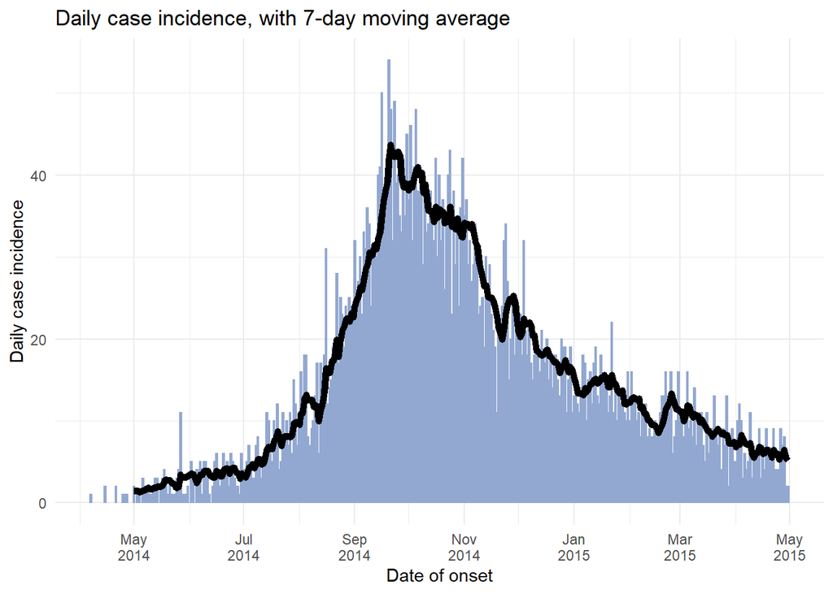

```r
# make daily count data
#######################
ll_counts_7day <- linelist %>%
  count(date_onset, name = "daily_cases")


# plot
######
ggplot(data = ll_counts_7day,   # use daily count data
       aes(x = date_onset,      # date x-axis
           y = daily_cases))+   # counts

  # histogram in the background
  geom_histogram(stat = "identity",    # height = value in the cell, not number of rows
                 color = "#92a8d1",    # color of lines within histogram
                 fill = "#92a8d1")+    # color of histogram

  # moving average line
  tidyquant::geom_ma(n = 7,            # window width
                     size = 2,         # line size
                     color = "black",  # line color
                     lty = "solid"     # line type ()
                     )+

  # labels for x-axis
  scale_x_date(date_breaks = "2 months",      # labels every 2 months
               date_minor_breaks = "1 month", # gridlines every month
               date_labels = '%b\n%Y')+       #labeled by month with year below

  # Choose color palette (uses RColorBrewer package)
  scale_fill_brewer(palette = "Pastel2")+

  theme_minimal()+

  labs(x = "Date of onset",
       y = "Daily case incidence",
       title = "Daily case incidence, with 7-day moving average")
```

#### Tentative data

The most recent data shown in epicurves should often be marked as tentative, or subject to reporting delays. This can be done in by adding a vertical line and/or rectangle over a specified number of days. Here are two options:

1. Use `annotate()`:
- **Pros:** Transparency of rectangle is easy. **Cons:** Items will not appear in legend.
- For a line use `annotate(geom = "segment")`. Provide `x`, `xend`, `y`, and `yend`. Adjust size, linetype (`lty`), and color.
- For a rectangle use `annotate(geom = "rect")`. Provide xmin/xmax/ymin/ymax. Adjust color and alpha.
2. Use `geom_segment()` and `geom_rect()`:
- **Pros:** Items can easily appear in legend. **Cons:** Difficult to achieve semi-transparency of rectangle.
- Provide the same x/y arguments as noted above for `annotate()`

*CAUTION:* While you can use `geom_rect()` to draw a rectangle, adjusting the transparency (alpha) does not work in a linelist context. This function overlays a rectangle for each observation/row!. Try a very low alpha (e.g. 0.01), or use `annotate(geom = "rect")` as shown.

##### **Using `annotate()`**

- Within `annotate(geom = "rect")`, the `xmin` and `xmax` arguments must be given inputs of class Date.
- Note that because these data are aggregated into weekly bars, and the last bar extends to the Monday after the last data point, the shaded region may appear to cover 4 weeks
- `annotate()` [online example](https://ggplot2.tidyverse.org/reference/annotate.html)

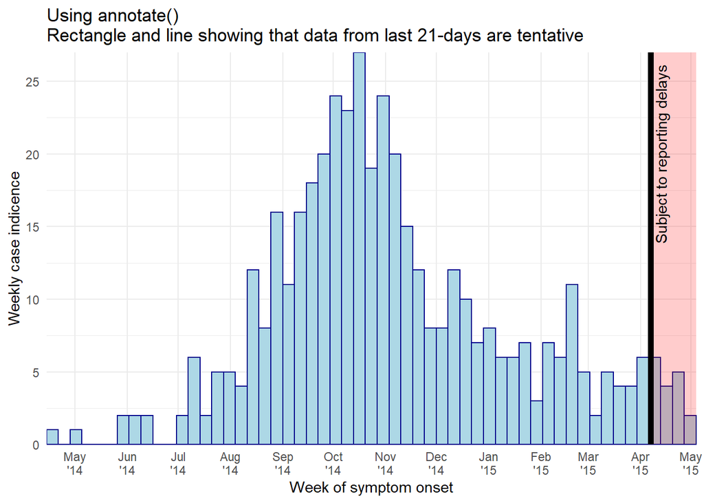

```r
ggplot(central_data, aes(x = date_onset)) +

  # histogram
  geom_histogram(
    breaks = seq.Date(
      from = as.Date(floor_date(min(central_data$date_onset, na.rm=T),   "week", week_start = 1)),
      to   = as.Date(ceiling_date(max(central_data$date_onset, na.rm=T), "week", week_start = 1)),
      by   = "7 days"),
    color = "darkblue",
    fill = "lightblue") +

  # scales
  scale_y_continuous(expand = c(0,0))+
  scale_x_date(
    expand = c(0,0),                   # remove excess x-axis space below and after case bars
    date_breaks = "1 month",           # 1st of month
    date_minor_breaks = "1 month",     # 1st of month
    date_labels = "%b\n'%y")+          # label format

  # labels and theme
  labs(title = "Using annotate()\nRectangle and line showing that data from last 21-days are tentative",
    x = "Week of symptom onset",
    y = "Weekly case indicence")+
  theme_minimal()+

  # add semi-transparent red rectangle to tentative data
  annotate("rect",
           xmin  = as.Date(max(central_data$date_onset, na.rm = T) - 21), # note must be wrapped in as.Date()
           xmax  = as.Date(Inf),                                          # note must be wrapped in as.Date()
           ymin  = 0,
           ymax  = Inf,
           alpha = 0.2,          # alpha easy and intuitive to adjust using annotate()
           fill  = "red")+

  # add black vertical line on top of other layers
  annotate("segment",
           x     = max(central_data$date_onset, na.rm = T) - 21, # 21 days before last data
           xend  = max(central_data$date_onset, na.rm = T) - 21,
           y     = 0,         # line begins at y = 0
           yend  = Inf,       # line to top of plot
           size  = 2,         # line size
           color = "black",
           lty   = "solid")+   # linetype e.g. "solid", "dashed"

  # add text in rectangle
  annotate("text",
           x = max(central_data$date_onset, na.rm = T) - 15,
           y = 20,
           label = "Subject to reporting delays",
           angle = 90)
```

The same black vertical line can be achieved with the code below, but using `geom_vline()` you lose the ability to control the height:

```
geom_vline(xintercept = max(central_data$date_onset, na.rm = T) - 21,
           size = 2,
           color = "black")
```

##### **Using `geom_segment()` and `geom_rect()`**

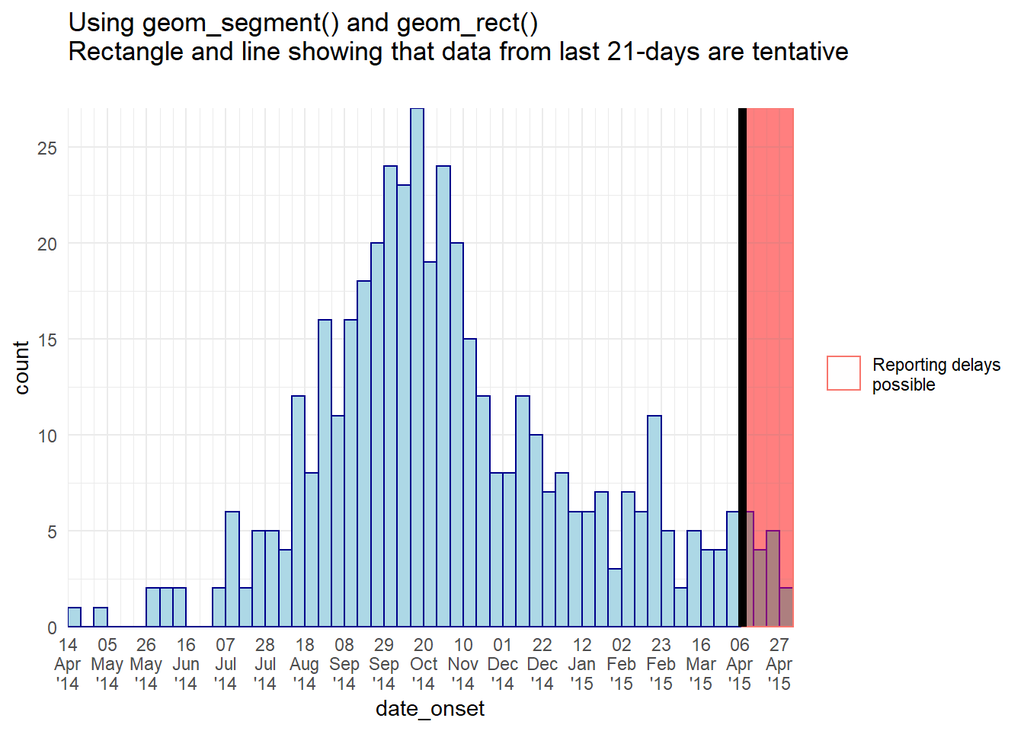

```r
ggplot(central_data, aes(x = date_onset)) +

  # histogram
  geom_histogram(
    breaks = seq.Date(
      from = as.Date(floor_date(min(central_data$date_onset, na.rm=T),   "week", week_start = 1)),
      to   = as.Date(ceiling_date(max(central_data$date_onset, na.rm=T), "week", week_start = 1)),
      by   = "7 days"),
    color = "darkblue",
    fill = "lightblue") +

  # scales
  scale_y_continuous(expand = c(0,0))+
  scale_x_date(
    expand = c(0,0),                   # remove excess x-axis space below and after case bars
    date_breaks = "3 weeks",           # Monday every 3 weeks
    date_minor_breaks = "week",        # Monday weeks
    date_labels = "%d\n%b\n'%y")+      # label format

  # labels and theme
  labs(title = "Using geom_segment() and geom_rect()\nRectangle and line showing that data from last 21-days are tentative",
    subtitle = "")+
  theme_minimal()+

  # make rectangle covering last 21 days
  geom_rect(aes(
              xmin  = as.Date(max(central_data$date_onset, na.rm = T) - 21), # note must be wrapped in as.Date()
              xmax  = as.Date(Inf),                                          # note must be wrapped in as.Date()
              ymin  = 0,
              ymax  = Inf,
              color = "Reporting delays\npossible"),    # sets label for legend (note: is within aes())
              alpha = .002,                             # !!! Difficult to adjust transparency with this option
           fill  = "red")+

  # make vertical line
  geom_segment(aes(x = max(central_data$date_onset, na.rm = T) - 21,
                   xend = max(central_data$date_onset, na.rm = T) - 21,
                   y = 0,
                   yend = Inf),
               color = "black",
               lty = "solid",
               size = 2)+
  theme(legend.title = element_blank())                 # remove title of legend
```

#### Multi-level date labels

Here is an option if you want multi-level date labels, without duplicating the lower label levels (e.g. for year or month).

Remember, you can can use tools like `\n` *within* the `date_labels` or `labels` arguments to put parts of each label on a new line below. However, the code below helps you take years or months (for example) on a lower line *and only once*.

A few notes on the code below:

- Case counts are aggregated into weeks for aesthetic reasons. See Epicurves page (aggregated data tab) for details.
- A line is used instead of a histogram, as the faceting approach below does not work well with histograms.

Aggreagate the weekly counts

```r
# Create dataset of case counts by week
#######################################
central_weekly <- linelist %>%
  filter(hospital == "Central Hospital") %>%           # filter linelist
  mutate(week = lubridate::floor_date(date_onset, unit = "weeks")) %>%
  count(week, .drop=F) %>%                             # summarize weekly case counts
  filter(!is.na(week)) %>%                             # remove cases with missing onset_date
  complete(week = seq.Date(from = min(week),           # fill-in all weeks with no cases reported
                           to   = max(week),
                           by   = "week"))
```

Make plots

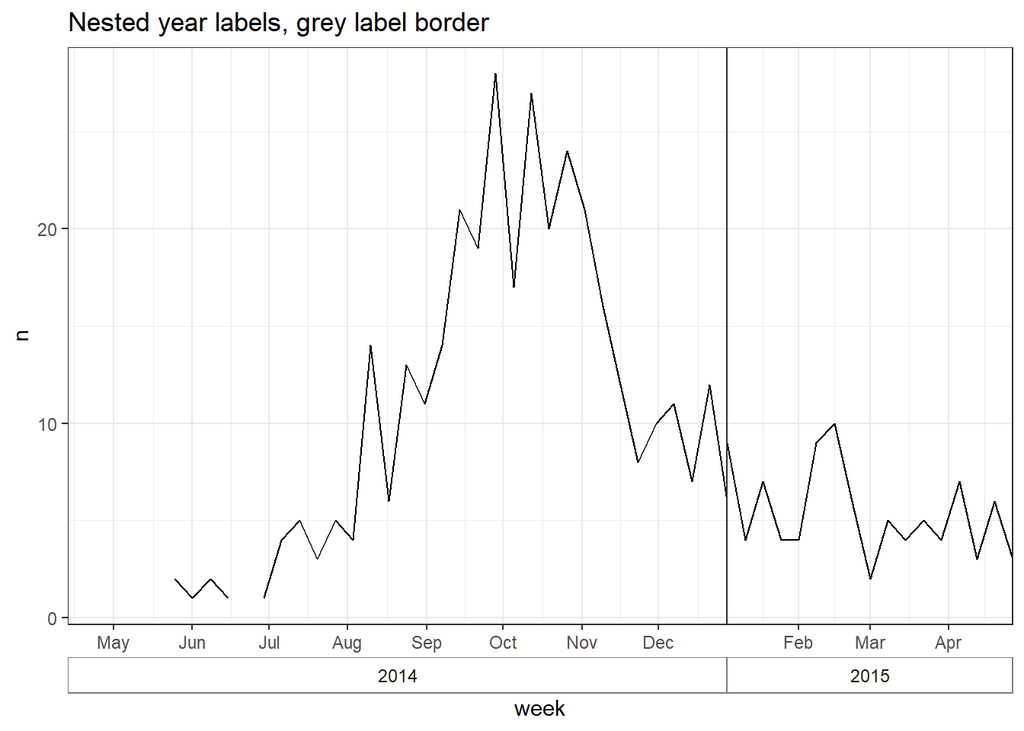

```r
# plot
######
ggplot(central_weekly) +
  geom_line(aes(x = week, y = n),    # make line, specify x and y
            stat = "identity") +             # because line height is count number
  scale_x_date(date_labels="%b",             # date label format show month
               date_breaks="month",          # date labels on 1st of each month
               expand=c(0,0)) +              # remove excess space
  facet_grid(~lubridate::year(week), # facet on year (of Date class column)
             space="free_x",
             scales="free_x",                # x-axes adapt to data range (not "fixed")
             switch="x") +                   # facet labels (year) on bottom
  theme_bw() +
  theme(strip.placement = "outside",         # facet labels placement
        strip.background = element_rect(fill = NA, # facet labels no fill grey border
                                        colour = "grey50"),
        panel.spacing = unit(0, "cm"))+      # no space between facet panels
  labs(title = "Nested year labels, grey label border")
```

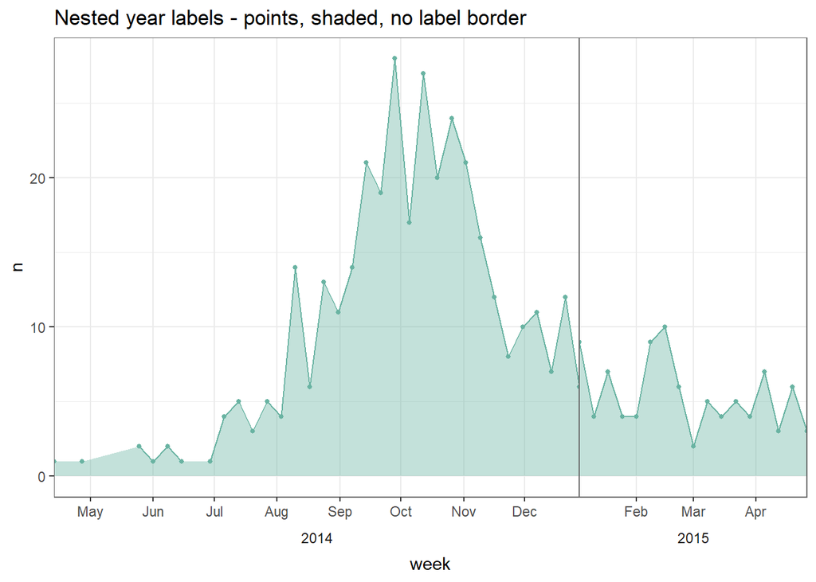

```r
# plot no border
################
ggplot(central_weekly,
       aes(x = week, y = n)) +              # establish x and y for entire plot
  geom_line(stat = "identity",              # make line, line height is count number
            color = "#69b3a2") +            # line color
  geom_point(size=1, color="#69b3a2") +     # make points at the weekly data points
  geom_area(fill = "#69b3a2",               # fill area below line
            alpha = 0.4)+                   # fill transparency
  scale_x_date(date_labels="%b",            # date label format show month
               date_breaks="month",         # date labels on 1st of each month
               expand=c(0,0)) +             # remove excess space
  facet_grid(~lubridate::year(week),   # facet on year (of Date class column)
             space="free_x",
             scales="free_x",               # x-axes adapt to data range (not "fixed")
             switch="x") +                  # facet labels (year) on bottom
  theme_bw() +
  theme(strip.placement = "outside",                     # facet label placement
          strip.background = element_blank(),            # no facet lable background
          panel.grid.minor.x = element_blank(),
          panel.border = element_rect(colour="grey40"),  # grey border to facet PANEL
          panel.spacing=unit(0,"cm"))+                   # No space between facet panels
  labs(title = "Nested year labels - points, shaded, no label border")
```

The above techniques were adapted from [this](https://stackoverflow.com/questions/44616530/axis-labels-on-two-lines-with-nested-x-variables-year-below-months) and [this](https://stackoverflow.com/questions/20571306/multi-row-x-axis-labels-in-ggplot-line-chart) post on stackoverflow.com.

#### Aggregating linelist data

To learn generally how to group and aggregate data, see the handbook page on Grouping/Aggregating.

In this circumstance, we demonstrate aggregating into weeks, months, and days.

##### **Weeks**

Create a new column that is weeks, then use `group_by()` with `summarize()` to get weekly case counts.

To aggregate into weeks and show ALL weeks (even ones with no cases), do this:

1. Create a new ‘week’ column within `mutate()`, using `floor_date()` from the **lubridate** package:
   - use `unit =` to set the desired time unit, e.g. "week`
   - use `week_start =` to set the weekday start of the week (7 = Sunday, 1 = Monday)
2. Follow with `complete()` to ensure that all weeks appear - even those with no cases.

For example:

```r
# Make dataset of weekly case counts
weekly_counts <- linelist %>%
  mutate(
    week = lubridate::floor_date(date_onset,
                                 unit = "week")) %>%  # new column of week of onset
  count(week) %>%                                     # group data by week and count rows per group
  filter(!is.na(week)) %>%                            # remove entries for cases missing date_onset
  complete(week = seq.Date(from = min(week),          # fill-in all weeks with no cases reported
                           to = max(week),
                           by="week")) %>%
  ungroup()                                           # deactivate grouping
```

Here are the first 50 rows of the resulting dataframe:

| week | n |
| --- | --- |
| 2014-04-06 | 1 |
| 2014-04-13 | 2 |
| 2014-04-20 | 4 |
| 2014-04-27 | 4 |
| 2014-05-04 | 11 |
| 2014-05-11 | 14 |
| 2014-05-18 | 14 |
| 2014-05-25 | 23 |
| 2014-06-01 | 21 |
| 2014-06-08 | 17 |

[output cut: 40 more lines]

```r
# Make dataset of weekly case counts
weekly_counts <- linelist %>%
  mutate(week = aweek::date2week(date_onset,          # new column of week of onset
                                 floor_day = T,       # show as weeks without weekday
                                 factor = TRUE)) %>%  # include all possible weeks
  count(week) %>%
  ungroup()                                           # deactivate grouping

# Optional: add column of start DATE for each week - e.g. for ggplot() when date x-axis is expected
# note: add this step AFTER the above code, to ensure all weeks are present
weekly_counts <- weekly_counts %>%
  mutate(week_as_date = aweek::week2date(week, week_start = "Monday")) # output is Monday date of each week
```

##### **Months**

To aggregate cases into months, again use `floor_date()` from the **lubridate** package, but with the argument `unit = "months"`. This rounds each date down to the 1st of its month. The output will be class Date.

Note that in the `complete()` step we also use “months”

```r
# Make dataset of weekly case counts
monthly_counts <- linelist %>%
  mutate(month = lubridate::floor_date(date_onset, unit = "months")) %>%   # new column, 1st of month of onset
  count(month) %>%
  filter(!is.na(month)) %>%
  complete(month = seq.Date(min(month),     # fill-in all months with no cases reported
                            max(month),
                            by="month"))
```

| month | n |
| --- | --- |
| 2014-04-01 | 8 |
| 2014-05-01 | 65 |
| 2014-06-01 | 99 |
| 2014-07-01 | 221 |
| 2014-08-01 | 531 |
| 2014-09-01 | 1082 |
| 2014-10-01 | 1111 |
| 2014-11-01 | 761 |
| 2014-12-01 | 560 |
| 2015-01-01 | 432 |

[output cut: 3 more lines]

##### **Days**

To aggregate a linelist into days, use the same approach but there is no need to create a new column. Use `group_by()` on the date column (e.g. `date_onset`).

If plotting a histogram, missing days in the data are not a problem as long as the column is class Date. However, it may be important for other types of plots or tables to have all possible days apear in the data. This is done with: `tidyr::complete()`

```r
# Make dataset of weekly case counts
daily_counts <- linelist %>%
  count(date_onset) %>%                           # count number of rows per unique date
  filter(!is.na(date_onset)) %>%                  # remove aggregation of rows that were missing date_onset
  complete(date_onset = seq.Date(min(date_onset), # ensure all days appear
                                 max(date_onset),
                                 by="day"))
```

## Aggregated data

Often instead of a linelist, you begin with aggregated counts from facilities, districts, etc. You can make an epicurve from `ggplot()` but the code will be slightly different. The incidence package does not support aggregate data.

This section will utilize the `count_data` dataset that was imported earlier, in the data preparation section. It is the `linelist` aggregated to day-hospital counts. The first 50 rows are displayed below.

| hospital | date_hospitalisation | n_cases |
| --- | --- | --- |
| Central Hospital | 2014-05-06 | 1 |
| Central Hospital | 2014-05-10 | 1 |
| Central Hospital | 2014-05-13 | 1 |
| Central Hospital | 2014-05-28 | 2 |
| Central Hospital | 2014-06-06 | 1 |
| Central Hospital | 2014-06-09 | 1 |
| Central Hospital | 2014-06-14 | 1 |
| Central Hospital | 2014-06-19 | 1 |
| Central Hospital | 2014-07-09 | 1 |
| Central Hospital | 2014-07-10 | 1 |

[output cut: 40 more lines]

As before, we must ensure date variables are correctly classified.

```r
# Convert Date variable to Date class
class(count_data$date_hospitalisation)
```

```
## [1] "Date"
```

We can plot a daily epicurve from these data. Here are the differences:

- Specify `y =` to the counts column within the primary aesthetics `aes()`
- Use of `stat = "identity"` within `geom_histogram()` indicates that the y-values could be counts from the `y =` column in `aes()`

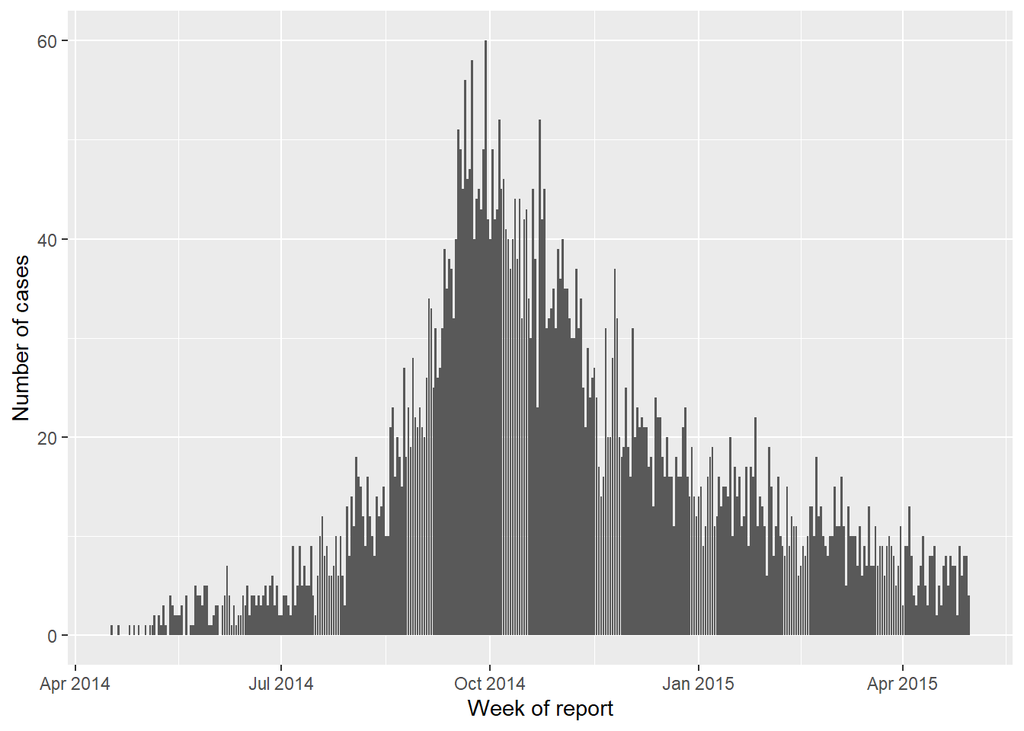

```r
ggplot(data = count_data, aes(x = as.Date(date_hospitalisation), y = n_cases))+
     geom_histogram(stat = "identity")+
     labs(x = "Week of report",
          y = "Number of cases",
          Title = "Daily case incidence, from daily count data")
```

**aggregate further**

To aggregated further, into weeks, we use the package **lubridate** and function `floor_date()`, as described above. Note that we use `group_by()` and `summarize()` in place of `count()` becase we need to `sum()` case counts instead of just counting the number of rows per group.

```r
# Create weekly dataset with epiweek column
count_data_weekly <- count_data %>%
  mutate(epiweek = lubridate::floor_date(date_hospitalisation, "week")) %>%
  group_by(hospital, epiweek, .drop=F) %>%
  summarize(n_cases_weekly = sum(n_cases, na.rm=T))
```

| hospital | epiweek | n_cases_weekly |
| --- | --- | --- |
| Central Hospital | 2014-05-04 | 2 |
| Central Hospital | 2014-05-11 | 1 |
| Central Hospital | 2014-05-25 | 2 |
| Central Hospital | 2014-06-01 | 1 |
| Central Hospital | 2014-06-08 | 2 |
| Central Hospital | 2014-06-15 | 1 |
| Central Hospital | 2014-07-06 | 3 |
| Central Hospital | 2014-07-13 | 7 |
| Central Hospital | 2014-07-27 | 5 |
| Central Hospital | 2014-08-03 | 6 |

[output cut: 40 more lines]

For the plotting we also specify the factor level order of `hospital`.

```r
count_data_weekly <- count_data_weekly %>%
  mutate(hospital = factor(hospital,
                           levels = c("Missing", "Port Hospital", "Military Hospital", "Central Hospital", "St. Mark's Maternity Hospital (SMMH)", "Other")))
```

Now plot by epiweek.

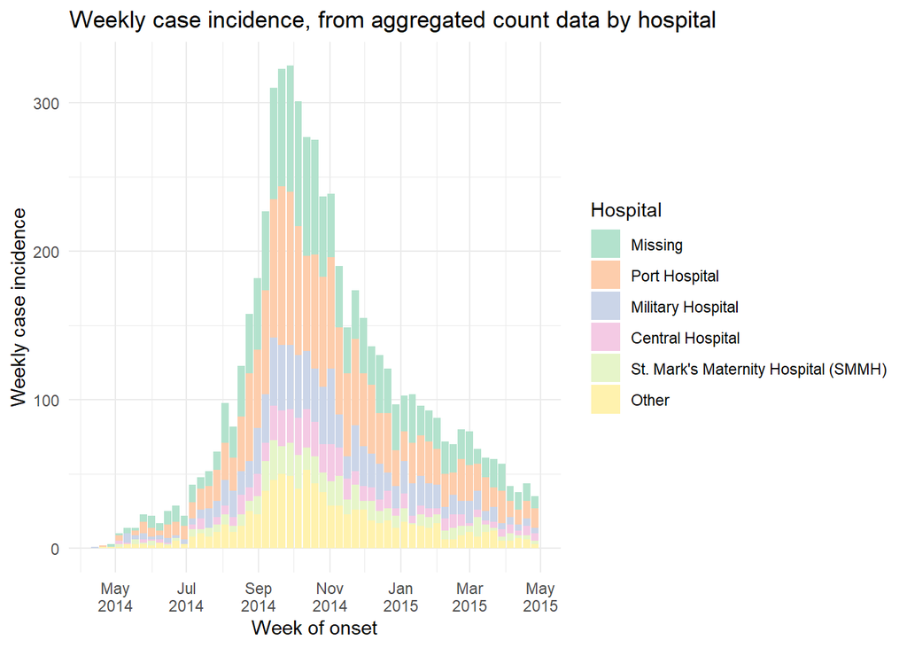

```r
ggplot(data = count_data_weekly,
       aes(x = epiweek,
           y = n_cases_weekly,
           group = hospital,
           fill = hospital))+

  geom_histogram(stat = "identity")+

  # labels for x-axis
  scale_x_date(date_breaks = "2 months",      # labels every 2 months
               date_minor_breaks = "1 month", # gridlines every month
               date_labels = '%b\n%Y')+       #labeled by month with year below

  # Choose color palette (uses RColorBrewer package)
  scale_fill_brewer(palette = "Pastel2")+

  theme_minimal()+

  labs(x = "Week of onset",
       y = "Weekly case incidence",
       fill = "Hospital",
       title = "Weekly case incidence, from aggregated count data by hospital")
```

## Dual-axis

Although there are fierce discussions about the validity of this within the data visualization community, many supervisors want to see an epicurve or similar chart with a percent overlaid with a second axis.

In ggplot it is difficult to do this, except for the case where you are showing a line reflecting the proportion of a category shown in the bars below.

See the handbook page on ggplot tips for details on how to make a second axis.

## Resources

Links to other online tutorials or resources.